# STA 326 2.0 Programming and Data Analysis with R

H.A.G.Amali Harshika AS2019365

2022-10-04

# **COVID 19 & AUSTRIA**

# **1.Introduction**

Austria, largely mountainous landlocked country of south-central Europe. Together with Switzerland, it forms what has been characterized as the neutral core of Europe, notwithstanding Austria’s full membership since 1995 in the supranational European Union (EU).

Austria is bordered to the north by the Czech Republic, to the northeast by Slovakia, to the east by Hungary, to the south by Slovenia, to the southwest by Italy, to the west by Switzerland and Liechtenstein, and to the northwest by Germany. It extends roughly 360 miles (580 km) from east to west.

## **1.1 visualization of location on world map**

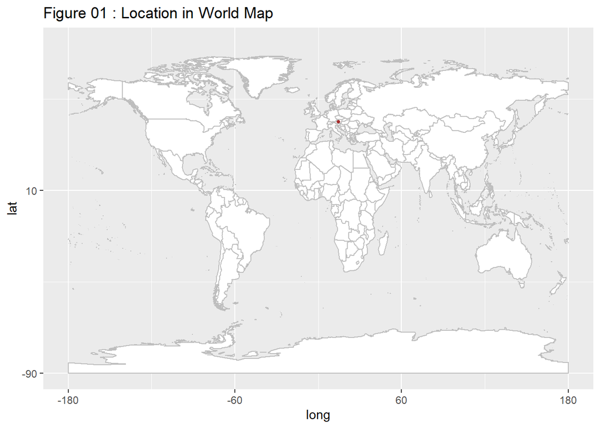

## **1.2 Climate**

The wooded slopes of the Alps and the small portion of the plains of southeastern Europe are characterized by differing climatic zones. The prevailing wind is from the west, and, therefore, humidity is highest in the west, diminishing toward the east. The wetter western regions of Austria have an Atlantic climate with a yearly rainfall of about 40 inches (1,000 mm); the drier eastern regions, under the influence of the more continental type of climate, have less precipitation.

In the lowlands and the hilly eastern regions, the median temperature ranges from about 30 °F (−1 °C) in January to about 68 °F (20 °C) in July. In those regions above 10,000 feet (3,000 metres), by contrast, the temperature range is between about 12 °F (−11 °C) in January, with a snow cover of approximately 10 feet (3 metres), and about 36 °F (2 °C) in July, with roughly 5 feet (1.5 metres) of snow cover.

## **1.4 Actions taken by Government**

- Stores selling non-essential goods as well as bars, restaurants, federal parks, sports facilities and public baths were forced to close. Supermarkets, chemist’s shops and pharmacies remained open. Air traffic was largely suspended.
- The restrictions included closure of cafes, restaurants, hairdressers and beauty salons, and all shops except those providing essential services and selling essential goods (e.g. grocery stores, pharmacies, post offices, gas stations, etc.) with an obligatory closing time of 7:00 pm. Primary schools joined secondary schools and universities in moving to distance learning

A 24-h curfew was introduced and people were allowed to leave their homes only for essential purposes such as: caring for other people or animals, family duties, outdoor exercise, and visiting religious institutions.

In order to react to the current circumstances regarding shut-downs of businesses, with retroactive effect from 1.3.2020, a new short-time-work model came into force which provides for significant improvements:

Shortened application periods, Higher funding Eased application process.

Austrian traffic light system

The Austrian traffic light system (Corona-Ampel) was introduced as a weekly epidemic risk assessment on a regional level.

# **2.Exploratary Data Analysis**

## **2.1 Analysis of Death,Confirmed,Recovered & Active cases**

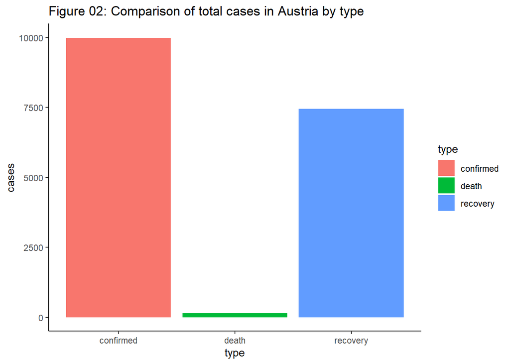

Here we considered about three types of Covid cases which are confirmed,deaths and recoveries.During pandemic season confirmed covid cases aew the highest among those two types.And also recoveries are higher than deaths.Overall this could be a good sign and actions taken by goverment are effective.

### **2.1.1 Visualization of confirmed cases**

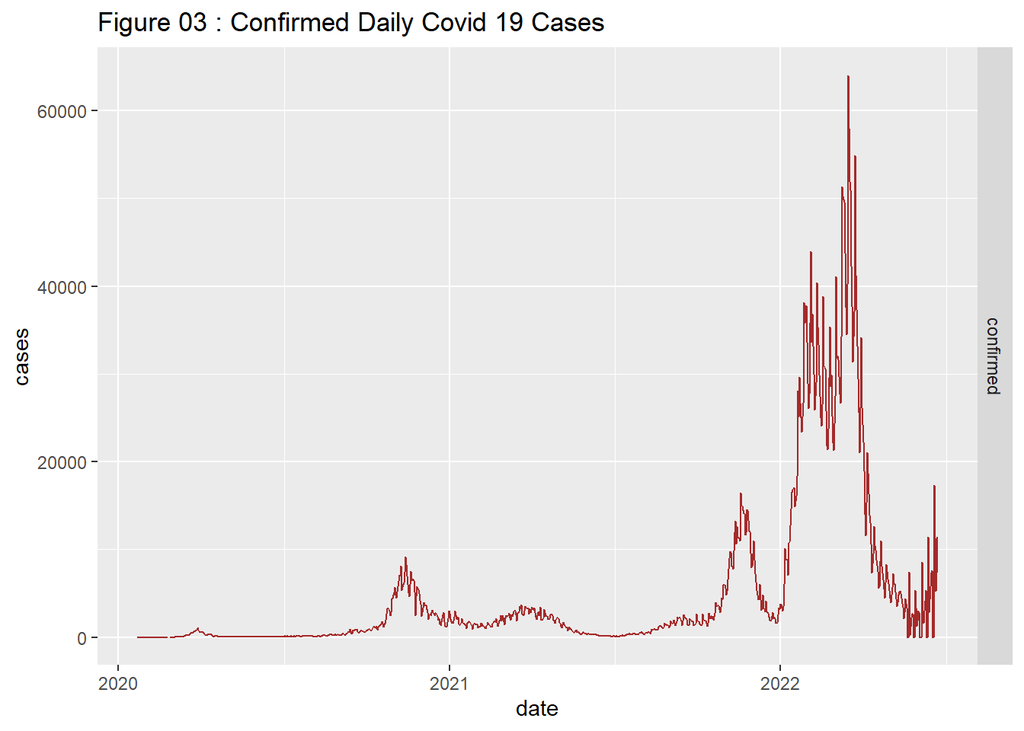

This data was collected till month june of 2022. According to this figure we can say that most confirmed cases were reported in year 2022.

### **2.1.2 Visualization of Deaths**

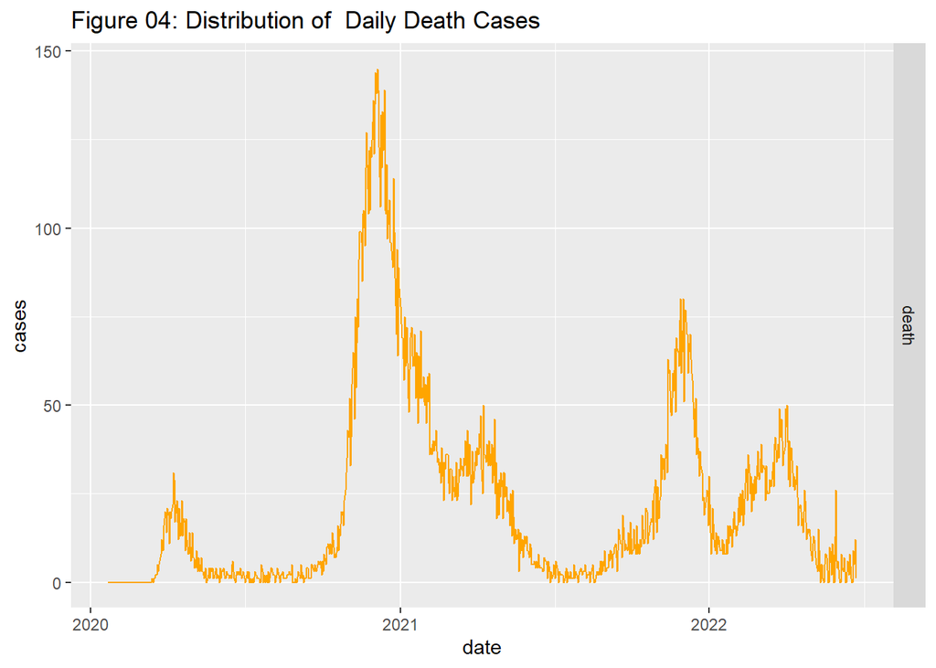

### **2.1.3 Visualization of Recoveries in covid pandemic**

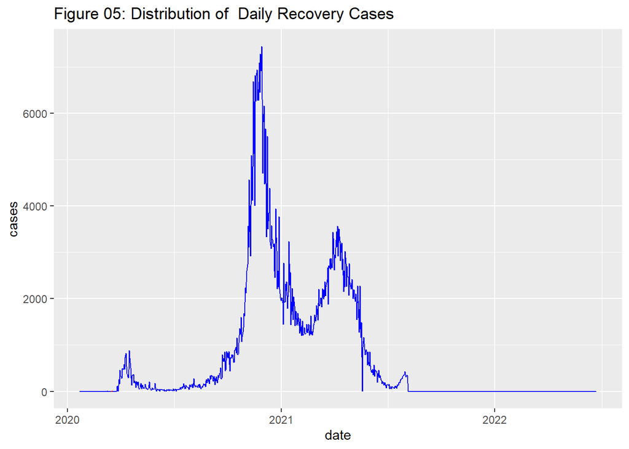

With the imposition of curfew , people stayed at home and led a healthy lifestyle.So recovery cases are increased among lockdown period.(late 2020-2021 year)

## **2.2 Distributions of covid case types**

### **2.2.1 Distribution of number of confirmed cases**

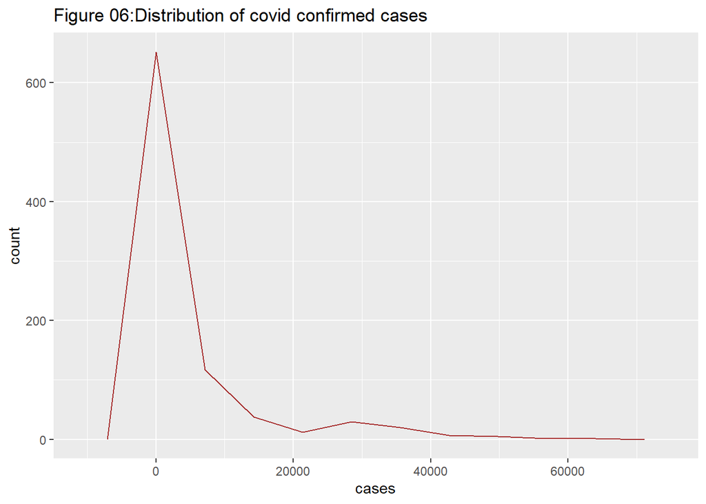

### **2.2.2 Distribution of number of Death cases**

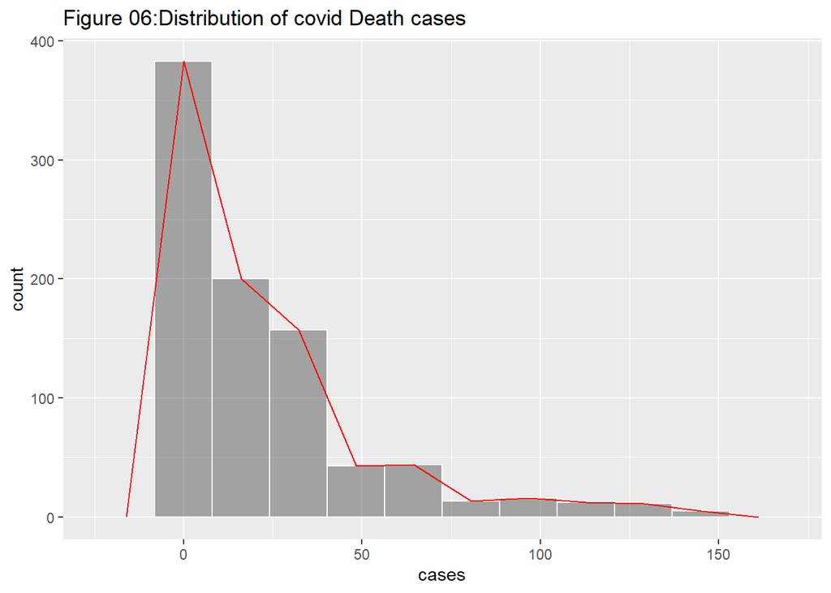

### **2.2.3 Distribution of number of Recovered cases**

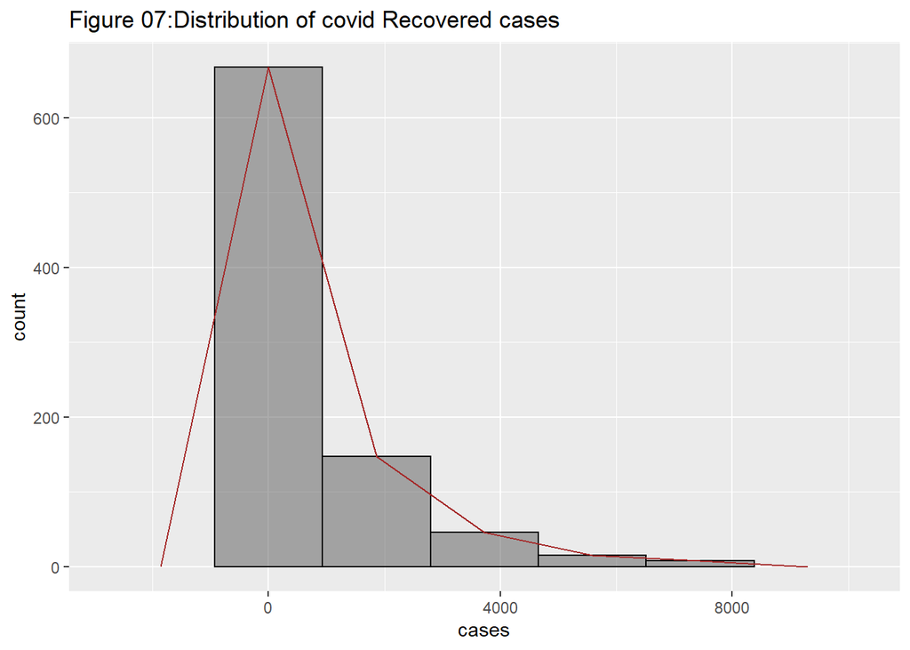

In this analysis we perform distribution of all three types of covid cases.

## **2.3 Comparisons of cases with other countries**

### **2.3.1 Comparisons with neighboring countries**

Austria is a large country located in South Central Europe. In this section we comparing effectiveness of Austria government’ virus prevention plan with regards to countries which are located near by Austria. We picked 4 countries.There are Germany,Switzerland,Italy and Slovakia.

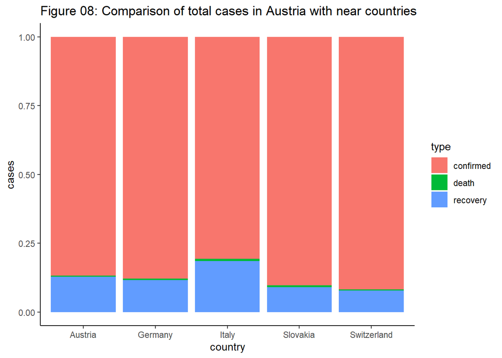

### **2.3.2 Comparison of Daily Confirmed , Death & Recovered cases of Austria with neighbouring countries**

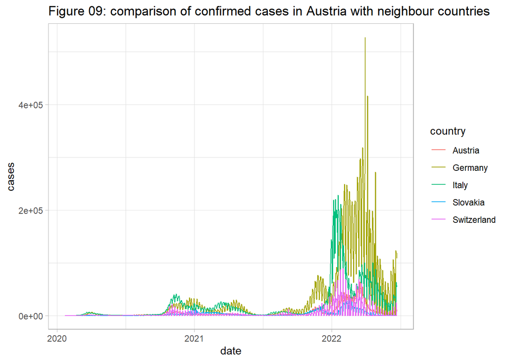

Per day confirmed cases in Austria is significantly less than Germany and Italy.There is an upward trend from late 2021 in Germany and Italy.

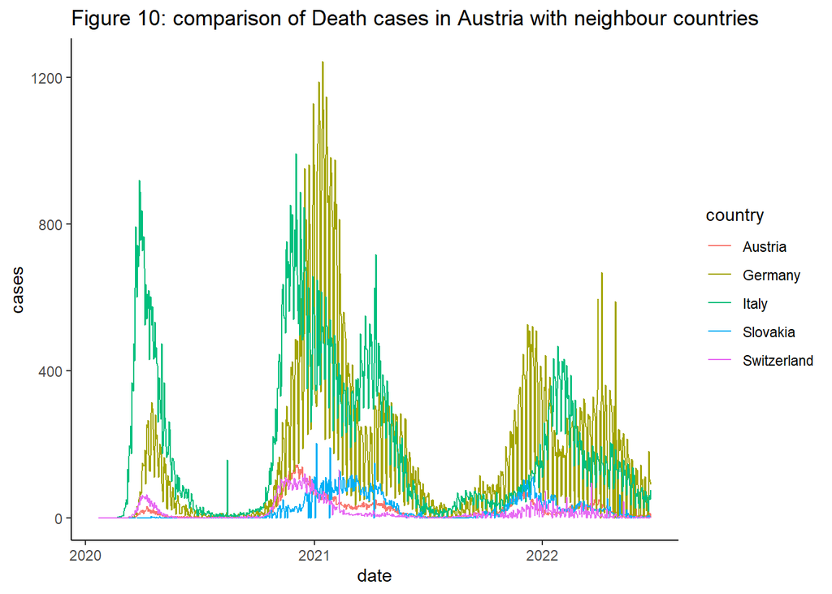

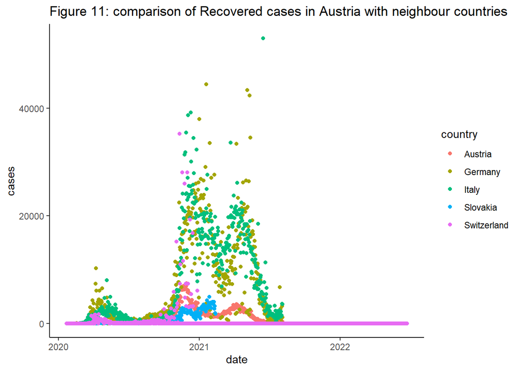

## **2.3.3 Comparisons of Total cases with other countries**

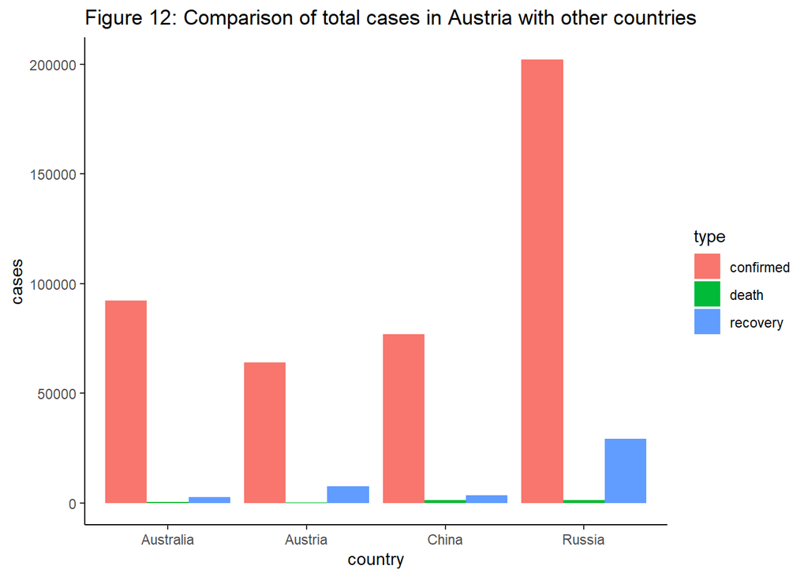

Here we compare Austria with other largest countries that covid has affected most. we picked 3 largest countries which are Russia,Australia and China. As we can see Russia has the most confirmed and recoery cases compared to other countries.

## **2.3.4 Comparisons of Confirmed,Recovered & Death cases in Austria with other countries**

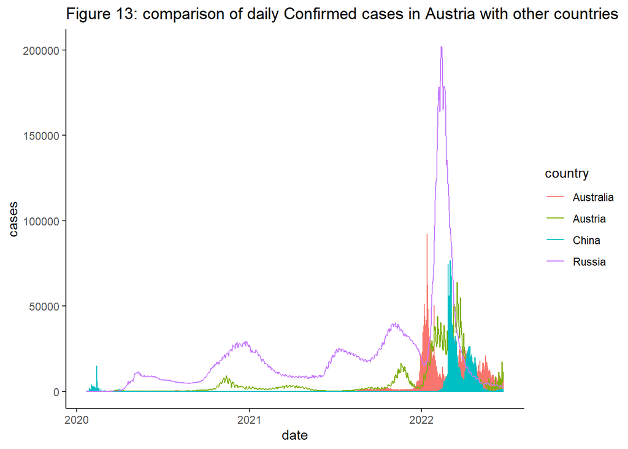

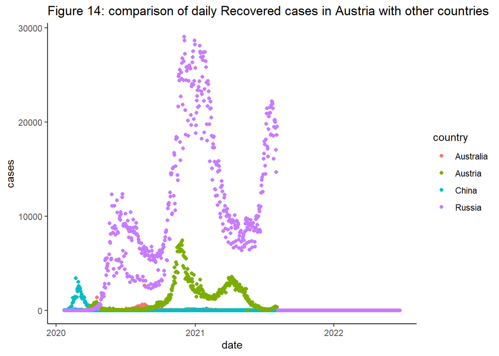

Most recovered cases are reported in Russia significantly higher than the other countries. Austria also has large number of recovery cases compared to China and Australia but its lower than Russia.

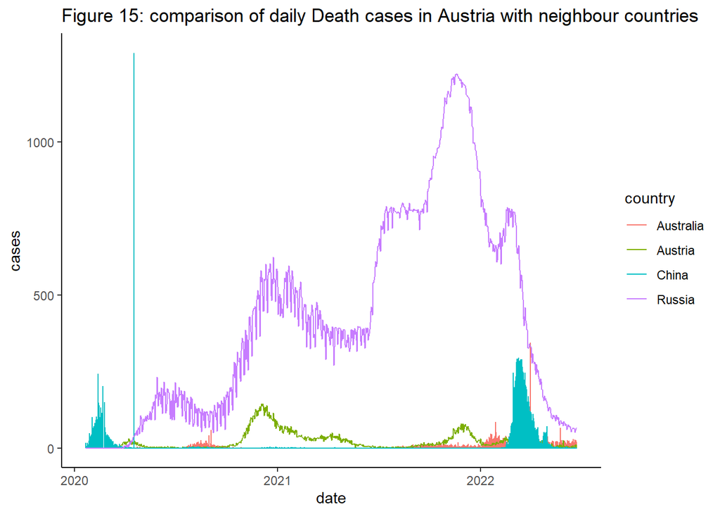

# **3.Conclusions**

3.According to these data we cannot forecast any of these covid types.

4.When compare with other countries Gremany and Italy have most confirmed cases and death cases.

5.After second wave of corona outbreak Austria’s death ratio was decreasing.Then we can see after government regulations loosen in 2021 death cases are increasing again due to carelessness of people.

# **4.Discussion**

COVID 19 is a highly contagious viral illness caused by severe acute respiratory syndrome.It has had devastating effect on the world’s demographics resulting in more than 5.3 million deaths worldwide.It has emerged as the most consequential global health crisis since the era of the Influenza pandemic of 1918.

Italy and Germany are the most affected in covid than Austria.Both these countries variation fo confirmed cases, deaths and recoveries significantly higher than Austria.

# **5.References**

[1] https://en.wikipedia.org/wiki/Austria

[2] https://ec.europa.eu/info/business-economy-euro/recovery-coronavirus/recovery-and-resilience-facility/austrias-recovery-and-resilience-plan_en#further-information

[3] https://ec.europa.eu/info/files/presentation-council-austrias-recovery-and-resilience-plan_en

[4] https://home.kpmg/governance

[5] https://at.usembassy.gov/covid-19-information/

[6] Douglas M, Katikireddi SV, Taulbut M, McKee M, McCartney G. Mitigating the wider health effects of covid-19 pandemic response. BMJ. 2020;369:m1557. https://doi.org/10.1136/bmj.m1557.

[7] imon J. COVID-19 in Austria. November 2020 ASPHER newsletter. The Association of Schools of Public Health in the European Region (ASPHER). 2020. https://www.aspher.org/download/527/aspher-newsletter-november-2020.pdf. Accessed 3 Mar 2021.

[8] Kreidl P, Schmid D, Maritschnik S, Richter L, Borena W, Genger JW, et al. Emergence of coronavirus disease 2019 (COVID-19) in Austria. Wien Klin Wochenschr. 2020;132(21):645–52. https://doi.org/10.1007/s00508-020-01723-9.

[9] https://www.britannica.com/place/Austria